# 2021 Capital BikeShare Data Exploration and Visualization

## Preliminary Wrangling

*NOTE: The 3-Day Membership replaced the 5-Day Membership in Fall 2011*

# Gathering data

```python
# Uncomment and Run this query to merge different files to one file fordgobike_2021.csv
"""folder_name = 'Data'
frames = [pd.read_csv(f) for f in glob.glob(os.path.join(folder_name, '*.csv'))]
result = pd.concat(frames, ignore_index=True)
result.to_csv('fordgobike_2021.csv', index=False)"""
```

```
"folder_name = 'Data'\nframes = [pd.read_csv(f) for f in glob.glob(os.path.join(folder_name, '*.csv'))]\nresult = pd.concat(frames, ignore_index=True)\nresult.to_csv('fordgobike_2021.csv', index=False)"
```

# Assessing data

```python
#Import all packages needed
import pandas as pd
import numpy as np
import matplotlib.pyplot as plt
%matplotlib inline
import seaborn as sns
from datetime import date
import os
import glob
import time
from math import radians, cos, sin, asin, sqrt
```

```python
# Load the data
data = pd.read_csv('fordgobike_2021.csv')
data.shape
```

```
(2749881, 13)
```

```python
#
def data_info(data):
    """
    This function helps in displaying the basic descriptive information
        ⁍ Shape
        ⁍ Number of duplicate values
        ⁍ unique index
        ⁍ Missing values in column
        ⁍Datatype of each column

    Parameter:
    data: Dataframe that requires the descriptive information
    """

    # Shape
    print("Shape of data: {}".format(data.shape))

    #Duplicates
    print("\n\nDuplicates : ",sum(data.duplicated()))

    #Checking the index is finite
    if data.index.is_unique:
        print("\n\nThe index is \033[1;3m unique \033[0m")
    else:
        print('\n\nThe index is \033[1;3m not unique \033[0m')

    # print only missing values
    print(" \033[1;3m \n\nMissing values:  \033[0m")
    missing_col =[]
    for col in data.columns:
        if data[col].isna().sum() > 0:
            print(col,':',data[col].isna().sum())
            missing_col.append(col)
    if len(missing_col) == 0:
        print('No missing values')
    print('\n\n')

    # Datatype
    print("\033[1;3m Datatype of each colum  \033[0m \n ",data.dtypes)

    #\033[1;3m' and '\033[0m
```

```python
data_info(data)
```

```
Shape of data: (2749881, 13)


Duplicates :  0


The index is  unique


Missing values:
start_station_name : 196326
start_station_id : 196326
end_station_name : 219259
end_station_id : 219259
start_lat : 2
start_lng : 2
end_lat : 4803
end_lng : 4803



 Datatype of each colum
  ride_id                object
rideable_type          object
started_at             object
ended_at               object
start_station_name     object
start_station_id       object
end_station_name       object
end_station_id         object
start_lat             float64
start_lng             float64
end_lat               float64
end_lng               float64
member_casual          object
dtype: object
```

# Cleaning

```python
start = time.time()

#Dropping rows with missing values
df = data.copy()
df = data[~data.end_station_id.isnull()]
df = df[~df.start_station_id.isnull()]
df = df[~df.start_lat.isnull()]

# Mapping Datatypes
df['started_at'] = pd.to_datetime(df['started_at'])
df['ended_at'] = pd.to_datetime(df['ended_at'])

df['ride_id'] = df['ride_id'].astype(str)
df['start_station_id'] = df['start_station_id'].astype(str)
df['end_station_id'] = df['end_station_id'].astype(str)

df['member_casual'] = df['member_casual'].astype('category')
df['rideable_type'] = df['rideable_type'].astype('category')

end = time.time()
print('Runtime : ',round((end - start),2),"s\n")
data_info(df)
```

```
Runtime :  7.57 s

Shape of data: (2454503, 13)


Duplicates :  0


The index is  unique


Missing values:
No missing values



 Datatype of each colum
  ride_id                       object
rideable_type               category
started_at            datetime64[ns]
ended_at              datetime64[ns]
start_station_name            object
start_station_id              object
end_station_name              object
end_station_id                object
start_lat                    float64
start_lng                    float64
end_lat                      float64
end_lng                      float64
member_casual               category
dtype: object
```

```python
start = time.time()

# New columns
df['travel_duration_in_mins'] = round((df.ended_at - df.started_at).astype('timedelta64[m]'),2)
df['start_date'] = df['started_at'].dt.strftime('%Y-%m-%d')
df['hour_of_day'] = df['started_at'].dt.strftime('%H')
df['weekday'] = df['started_at'].dt.strftime('%A')
df['month'] = df['started_at'].dt.strftime('%B')

# Wrangels category column
df['rideable_type'] =df['rideable_type'].str.replace('_', ' ')

# Maping datatype
weekday = ['Monday', 'Tuesday', 'Wednesday', 'Thursday', 'Friday', 'Saturday', 'Sunday']
weekdaycat = pd.api.types.CategoricalDtype(ordered=True, categories=weekday)
df['weekday'] = df['weekday'].astype(weekdaycat)

month = ['January', 'February', 'March', 'April', 'May', 'June', 'July', 'August', 'September', 'October', 'November', 'December']
monthcat = pd.api.types.CategoricalDtype(ordered=True, categories=month)
df['month'] = df['month'].astype(monthcat)


end = time.time()
print('Runtime : ',round((end - start),2),"s\n")
df.head()
```

```
Runtime :  54.14 s
```

|  | ride_id | rideable_type | started_at | ended_at | start_station_name | start_station_id | end_station_name | end_station_id | start_lat | start_lng | end_lat | end_lng | member_casual | travel_duration_in_mins | start_date | hour_of_day | weekday | month |
| --- | --- | --- | --- | --- | --- | --- | --- | --- | --- | --- | --- | --- | --- | --- | --- | --- | --- | --- |
| 0 | 4B413FB6647AEEA9 | classic bike | 2021-06-18 10:06:54 | 2021-06-18 10:09:50 | Massachusetts Ave & Dupont Circle NW | 31200.0 | 22nd & P ST NW | 31285.0 | 38.910100 | -77.044400 | 38.909394 | -77.048728 | member | 2.0 | 2021-06-18 | 10 | Friday | June |
| 1 | A522F316C4A1135D | classic bike | 2021-06-11 20:09:34 | 2021-06-11 20:29:50 | Tenleytown / Wisconsin Ave & Albemarle St NW | 31303.0 | Roosevelt Island | 31062.0 | 38.947607 | -77.079382 | 38.896553 | -77.067140 | member | 20.0 | 2021-06-11 | 20 | Friday | June |
| 2 | 35C5C0F6E8B5ADFA | classic bike | 2021-06-04 16:22:01 | 2021-06-04 16:30:21 | 20th St & Virginia Ave NW | 31259.0 | 34th & Water St NW | 31314.0 | 38.894722 | -77.045128 | 38.903731 | -77.067528 | member | 8.0 | 2021-06-04 | 16 | Friday | June |
| 3 | 54E9E750297ECFA8 | classic bike | 2021-06-01 17:52:03 | 2021-06-01 17:59:14 | 14th St & New York Ave NW | 31216.0 | 5th & K St NW | 31600.0 | 38.899632 | -77.031686 | 38.903040 | -77.019027 | member | 7.0 | 2021-06-01 | 17 | Tuesday | June |
| 4 | 1ADCF3D85015E238 | classic bike | 2021-06-18 09:24:29 | 2021-06-18 09:32:45 | Florida Ave & R St NW | 31503.0 | 5th & K St NW | 31600.0 | 38.912600 | -77.013500 | 38.903040 | -77.019027 | member | 8.0 | 2021-06-18 | 09 | Friday | June |

```python
data_info(df)
```

```
Shape of data: (2454503, 18)


Duplicates :  0


The index is  unique


Missing values:
No missing values



 Datatype of each colum
  ride_id                            object
rideable_type                      object
started_at                 datetime64[ns]
ended_at                   datetime64[ns]
start_station_name                 object
start_station_id                   object
end_station_name                   object
end_station_id                     object
start_lat                         float64
start_lng                         float64
end_lat                           float64
end_lng                           float64
member_casual                    category
travel_duration_in_mins           float64
start_date                         object
hour_of_day                        object
weekday                          category
month                            category
dtype: object
```

```python
start = time.time()

# Calculating the kms using the lat and long
def distance(lat1, lat2, lon1, lon2):

    # The math module contains a function named
    # radians which converts from degrees to radians.
    lon1 = radians(lon1)
    lon2 = radians(lon2)
    lat1 = radians(lat1)
    lat2 = radians(lat2)

    # Haversine formula
    dlon = lon2 - lon1
    dlat = lat2 - lat1
    a = sin(dlat / 2)**2 + cos(lat1) * cos(lat2) * sin(dlon / 2)**2

    c = 2 * asin(sqrt(a))

    # Radius of earth in kilometers. Use 3956 for miles
    r = 6371

    # calculate the result
    return round((c * r),2)

#calculating Distance travelled (Km)
df['travel_distance'] = df.apply(lambda row :distance(row['start_lat'], row['end_lat'], row['start_lng'], row['end_lng']),axis =1 )

end = time.time()
print('Runtime : ',round((end - start),2),"s\n")
```

```
Runtime :  91.58 s
```

```python
## Dropping rows where distance travelled is Zero and travel duration is negative
df = df[df.travel_distance>0.01]
df = df[df.travel_duration_in_mins >0.01]

data_info(df)

df = df[['rideable_type','start_station_name',  'end_station_name', 'member_casual',
         'travel_duration_in_mins', 'start_date', 'hour_of_day','weekday',
         'month', 'travel_distance']]
df.to_csv('fordgobike_2021_cleaned.csv', index=False)
```

```
Shape of data: (2274556, 19)


Duplicates :  0


The index is  unique


Missing values:
No missing values



 Datatype of each colum
  ride_id                            object
rideable_type                      object
started_at                 datetime64[ns]
ended_at                   datetime64[ns]
start_station_name                 object
start_station_id                   object
end_station_name                   object
end_station_id                     object
start_lat                         float64
start_lng                         float64
end_lat                           float64
end_lng                           float64
member_casual                    category
travel_duration_in_mins           float64
start_date                         object
hour_of_day                        object
weekday                          category
month                            category
travel_distance                   float64
dtype: object
```

```python
df.head()
```

|  | rideable_type | start_station_name | end_station_name | member_casual | travel_duration_in_mins | start_date | hour_of_day | weekday | month | travel_distance |
| --- | --- | --- | --- | --- | --- | --- | --- | --- | --- | --- |
| 0 | classic bike | Massachusetts Ave & Dupont Circle NW | 22nd & P ST NW | member | 2.0 | 2021-06-18 | 10 | Friday | June | 0.38 |
| 1 | classic bike | Tenleytown / Wisconsin Ave & Albemarle St NW | Roosevelt Island | member | 20.0 | 2021-06-11 | 20 | Friday | June | 5.77 |
| 2 | classic bike | 20th St & Virginia Ave NW | 34th & Water St NW | member | 8.0 | 2021-06-04 | 16 | Friday | June | 2.18 |
| 3 | classic bike | 14th St & New York Ave NW | 5th & K St NW | member | 7.0 | 2021-06-01 | 17 | Tuesday | June | 1.16 |
| 4 | classic bike | Florida Ave & R St NW | 5th & K St NW | member | 8.0 | 2021-06-18 | 09 | Friday | June | 1.17 |

# Visualization

### What is the structure of your dataset?

> The original combined data contains approximately 27,49,881 individual trip records with 13 variables collected. The variables can be divided into 3 major categories:
> - Trip details
> - station informations
> - user type
> - Dervied columns to assist exploration

### What is/are the main feature(s) of interest in your dataset?

> I'm exploring the bike trips' duration along user characteristics, i.e.
> - When do they ride?
> - How far do they go?
> - Which stations are most popular?
> - What days of the week are most rides taken on?

### What features in the dataset do you think will help support your investigation into your feature(s) of interest?

> - Each trip's start date/time and duration information will help understanding how long a trip usually takes and when.
> - The user type column (member_casual) helps in analysing the behavioural pattern between different groups. # Univariate Exploration

```python
def set_custom_palette(series, highlight_color = 'turquoise', other_color = 'lightgrey', highlight = 'Max'):

    if highlight == 'Max':
        val = series.max()
    if highlight == 'Min':
        val = series.min()
    pal = []
    for item in series:
        if item == val:
            pal.append(highlight_color)
        else:
            pal.append(other_color)
    return pal

# Barchart
def barplot(x , y, color = '#79DAE8', orient = None, order = None, palette = None, xlabel = None, ylabel = None, title = None, show_values = False):
    fig, ax = plt.subplots(figsize = (15,8))
    ax = sns.barplot(x=x, y = y,  color = color, order=order,palette = palette, orient = orient)
    if show_values:
        ax.bar_label(ax.containers[0])
    if xlabel is not None:
        plt.xlabel(xlabel)
    if ylabel is not None:
        plt.ylabel(ylabel)
    if title is not None:
        plt.title(title)
    sns.despine(bottom = True, left = True)
    plt.show()
```

### What is the longest travel in the year 2021?

```python
longest_travel = df.nlargest(5,'travel_distance')
longest_travel[['start_station_name', 'end_station_name','travel_distance', 'travel_duration_in_mins']]
```

|  | start_station_name | end_station_name | travel_distance | travel_duration_in_mins |
| --- | --- | --- | --- | --- |
| 698137 | Vy Reston Heights | Potomac Ave & Half St SW | 31.08 | 198.0 |
| 1371096 | 3rd & H St NW | Reston Town Center Transit Station | 30.48 | 316.0 |
| 1371483 | 3rd & H St NW | Reston Town Center Transit Station | 30.48 | 316.0 |
| 1351006 | 3rd & H St NW | Sunset Hills & Old Reston Ave | 29.75 | 342.0 |
| 1351014 | 3rd & H St NW | Sunset Hills & Old Reston Ave | 29.75 | 346.0 |

> The **longest travel was 31.08 Kms** from Vy Reston Heights to Potomac Ave & Half St SW.

$\;\;\;\;\;\;$

### Which is the popular start destination in the year 2021?

```python
print("Popular start station: \n",df['start_station_name'].value_counts()[:5])
```

```
Popular start station:
 New Hampshire Ave & T St NW    26307
Lincoln Memorial               26031
15th & P St NW                 24979
4th St & Madison Dr NW         23737
1st & M St NE                  22845
Name: start_station_name, dtype: int64
```

> **New Hampshire Ave & T St NW** is the popular start destination. followed by Lincoln Memorial

$\;\;\;\;\;\;$

### What is the popular end destination in the year 2021?

```python
print("\n\nPopular end station: \n",df['end_station_name'].value_counts()[:5])
```

```
Popular end station:
 New Hampshire Ave & T St NW    26053
15th & P St NW                 25631
Lincoln Memorial               25097
1st & M St NE                  23503
4th St & Madison Dr NW         23010
Name: end_station_name, dtype: int64
```

$\;\;\;\;\;\;$

### On Which hour of the day people ride the most ?

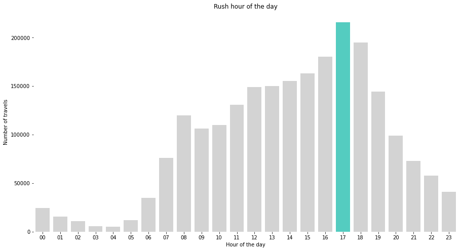

```python
barplot(df['hour_of_day'].value_counts().sort_index().index,
            df['hour_of_day'].value_counts().sort_index().values,
            palette=set_custom_palette(df['hour_of_day'].value_counts().sort_index().values, highlight= 'Max'),
           xlabel = 'Hour of the day', ylabel = 'Number of travels', title = 'Rush hour of the day')
```

> **5pm is the most rush time** it may be due to the end of the workday.

$\;\;\;\;\;\;$

### On what day people ride most?

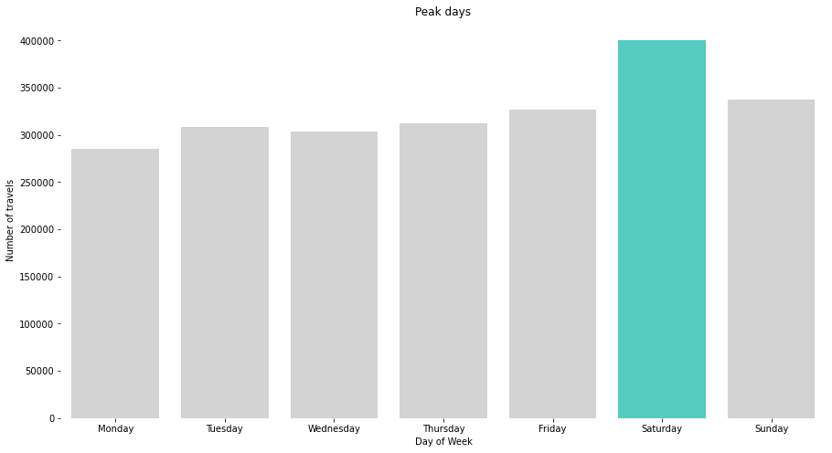

```python
barplot(df['weekday'].value_counts().index,
            df['weekday'].value_counts().values,
            palette=set_custom_palette(df['weekday'].value_counts().sort_index().values, highlight= 'Max'),
           xlabel = 'Day of Week', ylabel = 'Number of travels', title = 'Peak days')
```

> As **Saturday** is the start of weekend there are more number of users who are taking trip around.

$\;\;\;\;\;\;$

### Which month has the most trips?

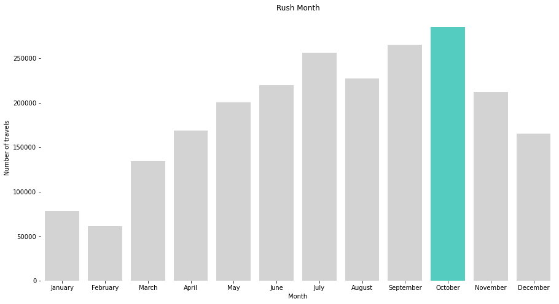

```python
barplot(df['month'].value_counts().index,
            df['month'].value_counts().values,
            palette=set_custom_palette(df['month'].value_counts().sort_index().values, highlight= 'Max'),
           xlabel = 'Month', ylabel = 'Number of travels', title = 'Rush Month')
```

> - Most of the trips are taken in the month of **october**
> - We can also see an increase in users in the year 2021 from March to July

$\;\;\;\;\;\;$

### What type of users takes most of the ride?

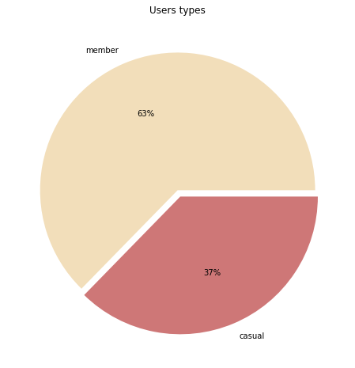

```python
plt.figure(figsize=(8,8))
cols = ['#F2DEBA', '#CE7777']
explode = [0, 0.05]
plt.pie(df['member_casual'].value_counts(), labels =df['member_casual'].value_counts().index , autopct='%.0f%%', explode=explode, colors = cols);
plt.title('Users types');
```

> Most of the trips are by the **people who has an Annual Member, 30-Day Member or Day Key Member**

$\;\;\;\;\;\;$

### How different user types ride on each day?

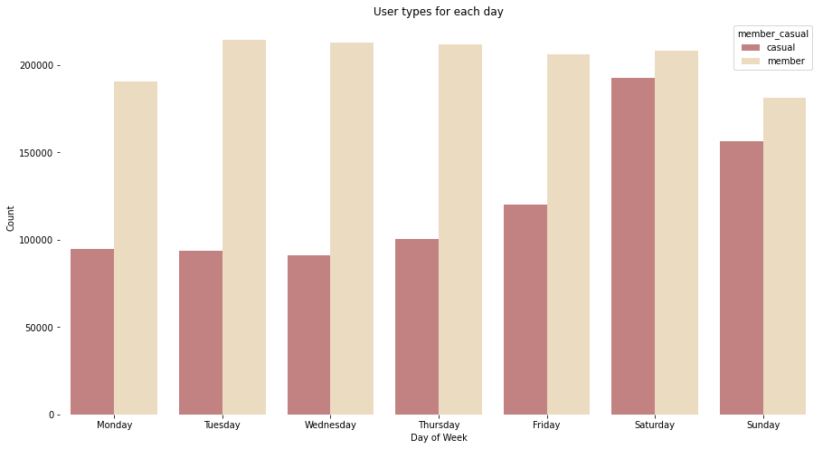

```python
plt.figure(figsize = (15,8))
sns.countplot(data=df, x='weekday', hue='member_casual', palette=['#CE7777', '#F2DEBA'] )
plt.xlabel('Day of Week')
sns.despine(bottom = True, left = True)
plt.title('User types for each day')
plt.ylabel('Count');
```

> - we can observer that on the start of the weekend i.e., **Saturday there is a massive increase in the casual users**. It can probably be the reason for the increase in trave duration as traffic may increase.

$\;\;\;\;\;\;$

### What are the different typed of bikes used by user types?

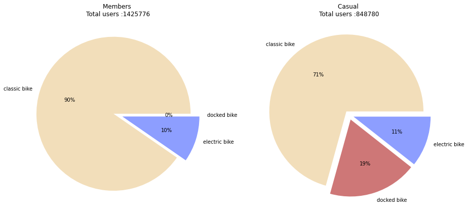

```python
member_df = df[df.member_casual == 'member']
casual_df = df[df.member_casual == 'casual']

fig, ax = plt.subplots(1,2,figsize = (15,15))
cols1 = ['#F2DEBA', '#8D9EFF']
cols2 = ['#F2DEBA', '#CE7777' , '#8D9EFF']
exp = [0.06,0.06,0.06]

ax[0].pie(member_df['rideable_type'].value_counts(), labels =member_df['rideable_type'].value_counts().index , autopct='%.0f%%', explode = exp,
          colors = cols1);
ax[0].set_title('Members \nTotal users :'+str(member_df.shape[0]));
ax[1].pie(casual_df['rideable_type'].value_counts(), labels =casual_df['rideable_type'].value_counts().index , autopct='%.0f%%', explode = exp, colors = cols2);
ax[1].set_title('Casual \nTotal users :'+str(casual_df.shape[0]));
```

> - **Classic bike is the most preffered type** by both members & casual users.
> - Members do not use the docked bikes whereas casual members use it 19%

$\;\;\;\;\;\;$

### Which month has the higest usage on electric bikes?

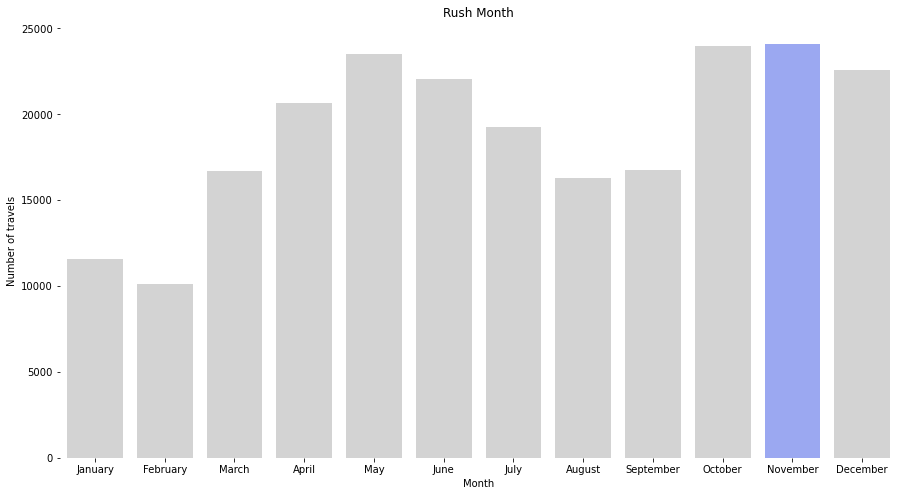

```python
plt_df = df[(df['rideable_type'] == 'electric bike')]
barplot(plt_df['month'].value_counts().index,
            plt_df['month'].value_counts().values,
            palette=set_custom_palette(plt_df['month'].value_counts(sort=False).values, highlight_color= '#8D9EFF',highlight= 'Max'),
           xlabel = 'Month', ylabel = 'Number of travels', title = 'Rush Month')
```

> Electric bikes are highly used in **November 2021**

$\;\;\;\;\;\;$

### What is the time taken by most of the rides?

```python
df['travel_duration_in_mins'].describe(percentiles=[0.95])
```

```
count    2.274556e+06
mean     2.069458e+01
std      2.107913e+02
min      1.000000e+00
50%      1.200000e+01
95%      5.000000e+01
max      5.454000e+04
Name: travel_duration_in_mins, dtype: float64
```

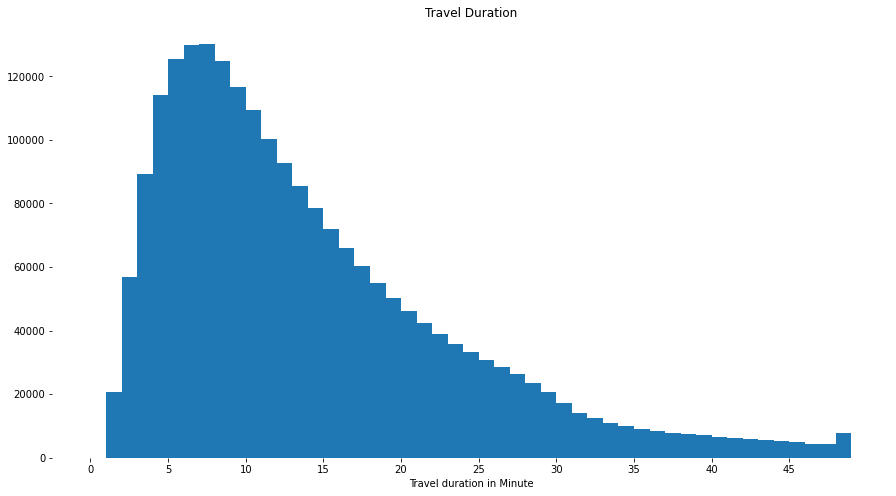

```python
plt.figure(figsize = (15,8))
bins = np.arange(0, 50, 1)
ticks = np.arange(0, 50, 5)
plt.hist(data=df, x='travel_duration_in_mins', bins=bins);
plt.xticks(ticks, ticks);
sns.despine(bottom = True, left = True)
plt.xlabel('Travel duration in Minute');
plt.title('Travel Duration');

df = df[df['travel_duration_in_mins'] <= 50 ]
```

> - Most of the rides are take between 5 to 15 mins

$\;\;\;\;\;\;$

### Discuss the distribution(s) of your variable(s) of interest. Were there any unusual points? Did you need to perform any transformations?

- There is a increase in the usage around 12pm - 5pm during the day, The number of rides take on weekend are high as more number of casual user are taking their rides.
- We can observe the increase in the user type during the summer month i.e. March - July
- The most used type of bike was classic by both the members and users. Docked bikes are only used by the casual riders.
- Most of the rides taken were shorter and quicker.

No transformation was requrired for this analysis

### Of the features you investigated, were there any unusual distributions? Did you perform any operations on the data to tidy, adjust, or change the form of the data? If so, why did you do this?

The distribution of the ride duration messier when plotting out the original data. The describe() and xticks() are used to zoom in to a smaller range where 95% trip records fell, which made the distribution much clearer. In order to help focusing on the main cases of typical use of the system.

$\;\;\;\;\;\;$

# Bivariate Exploration

### On which day the travel takes longer than usual?

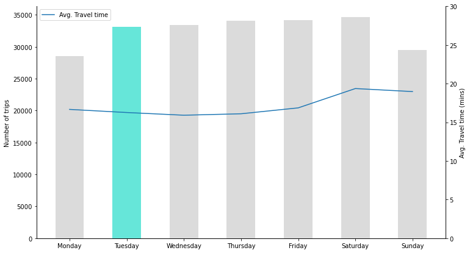

```python
# Create figure and axis #1
fig, ax1 = plt.subplots(figsize=(12,7))
c = ['lightgrey','turquoise','lightgrey','lightgrey','lightgrey','lightgrey','lightgrey']
# plot line chart on axis #1
ax1.bar(plt_df['weekday'].value_counts(sort=False).index,plt_df['weekday'].value_counts(sort=False).values, width=0.5, alpha=0.8, color=c)
ax1.grid(False) # turn off grid #2
ax1.set_ylabel('Number of trips')
#ax1.bar_label(ax1.containers[0])

# set up the 2nd axis
ax2 = ax1.twinx()

# plot bar chart on axis #2
ax2.plot(plt_df['weekday'].value_counts(sort=False).index, plt_df.groupby('weekday')['travel_duration_in_mins'].mean())
ax2.set_ylabel('Avg. Travel time (mins)')
ax2.set_ylim(0, 30)
ax2.legend(['Avg. Travel time'], loc="upper left")

sns.despine(right = False)
plt.show()
```

> - We can clearly state that since saturdays is most rush day, the average time taken for a ride is greater than the usual time.
> - We can also see that even if the **number of rides has increased by 16% on Tuesday the Avg time taken for the ride did not significantly increase**. (Interesting)

$\;\;\;\;\;\;$

### What is the average trip duration for different users?

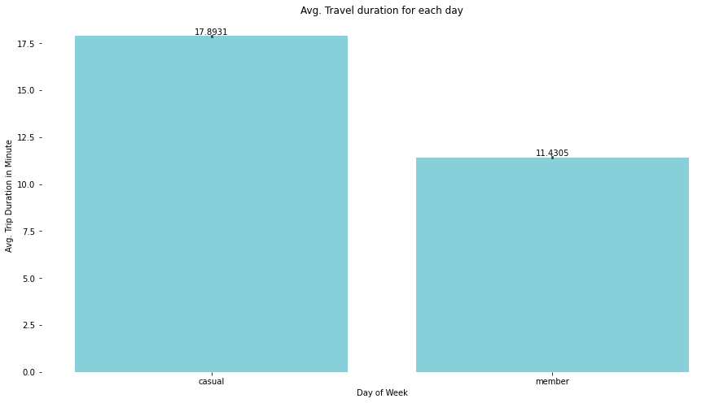

```python
barplot(df['member_casual'], df['travel_duration_in_mins'],
        xlabel = 'Day of Week', ylabel= 'Avg. Trip Duration in Minute', title= 'Avg. Travel duration for each day', show_values=True)
```

> - **Casual users tend travel 1.6x longer than the people who has subscription.**

$\;\;\;\;\;\;$

### Did you observe any interesting relationships between the other features (not the main feature(s) of interest)?

It is interesting to see that number of rides increased on Tuesdays and the average travel duration decreased. This may be a cause that more number of short rides taken.

$\;\;\;\;\;\;$

# Multivariate Exploration

### At what time most of the rides take place during a day? Compare the pattern betweent differnet users

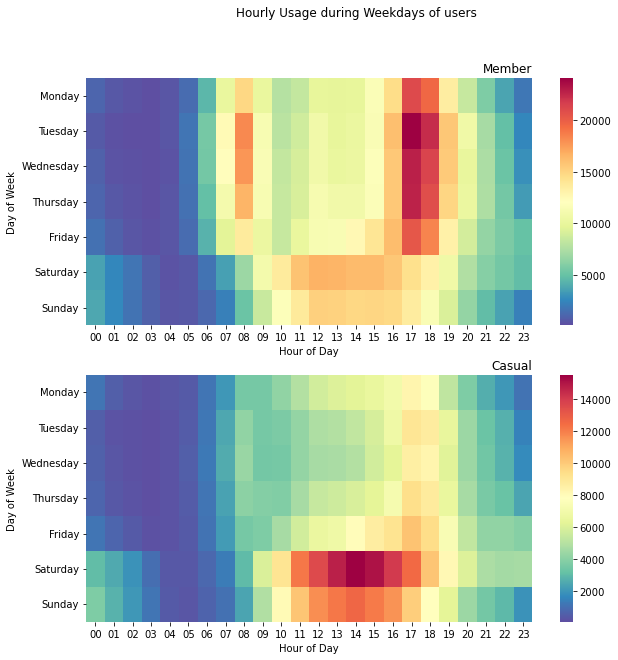

```python
plt.figure(figsize=(10,10))
plt.suptitle('Hourly Usage during Weekdays of users');

plt.subplot(2, 1, 1)
members = df.query('member_casual == "member"')
ct_counts = members.groupby(['weekday', 'hour_of_day']).size()
ct_counts = ct_counts.reset_index(name='count')
ct_counts = ct_counts.pivot(index='weekday', columns='hour_of_day', values='count')
sns.heatmap(ct_counts, cmap='Spectral_r');
plt.title('Member', loc='right');
plt.xlabel('Hour of Day');
plt.ylabel('Day of Week');

plt.subplot(2, 1, 2)
casual = df.query('member_casual == "casual"')
st_counts = casual.groupby(['weekday', 'hour_of_day']).size()
st_counts = st_counts.reset_index(name='count')
st_counts = st_counts.pivot(index='weekday', columns='hour_of_day', values='count')
sns.heatmap(st_counts, cmap='Spectral_r');
plt.title('Casual', loc='right');
plt.xlabel('Hour of Day');
plt.ylabel('Day of Week');
```

> - People who has subscription (Member) tend to travel in the weekday and during the end of working hours
> - People with no subscription (Casual) travel mostly on weekends and on lesuire hours.

$\;\;\;\;\;\;$

### Compare the distance travelled by each user type?

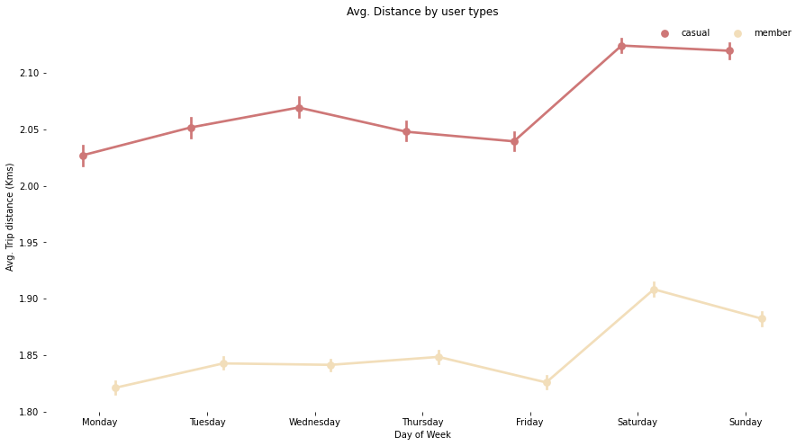

```python
plt.figure(figsize = (15,8))
sns.pointplot(data=df, x='weekday', y='travel_distance', hue='member_casual', dodge=0.3,palette=['#CE7777', '#F2DEBA'] );
plt.xlabel('Day of Week');
plt.ylabel('Avg. Trip distance (Kms)');
plt.title('Avg. Distance by user types');
plt.legend(loc = "upper right", ncol = 2, frameon = False)
sns.despine(bottom = True, left = True)
```

$\;\;\;\;\;\;$

### Compare the travel time taken by each user type?

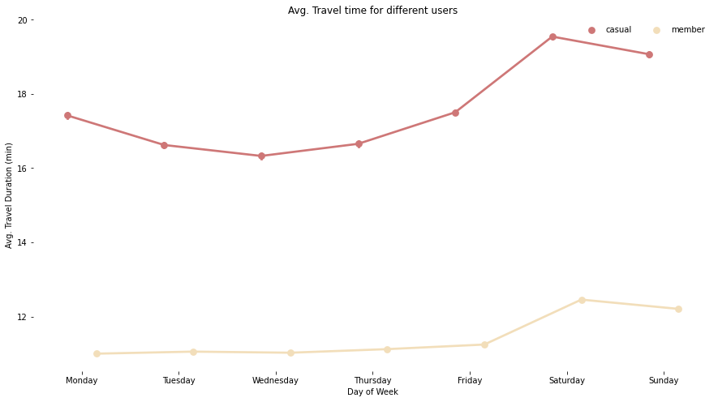

```python
plt.figure(figsize = (15,8))
sns.pointplot(data=df, x='weekday', y='travel_duration_in_mins', hue='member_casual', dodge=0.3,palette=['#CE7777', '#F2DEBA'] );
plt.xlabel('Day of Week');
plt.ylabel('Avg. Travel Duration (min)');
plt.title('Avg. Travel time for different users');
plt.legend(loc = "upper right", ncol = 2, frameon = False)
sns.despine(bottom = True, left = True)
```

> - Members who take ride take small short amount of time during the weekdays due to travel a short distance which is evident from the previous graph
> - Casual rides take littel longer than members.
> - There is a significant rise in the travel duration as weekends due increased rides.

$\;\;\;\;\;\;$

### Which type of bike is mostly used for the long rides?

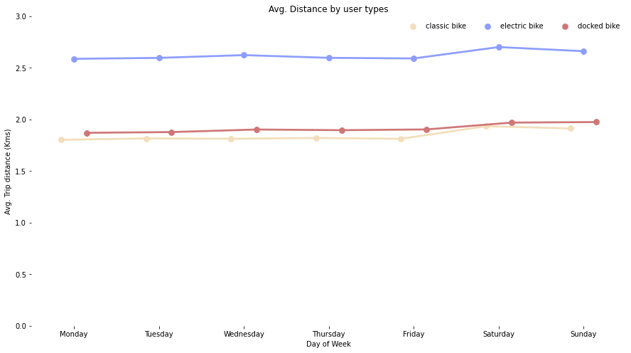

```python
plt.figure(figsize = (15,8))
sns.pointplot(data=df, x='weekday', y='travel_distance', hue='rideable_type', dodge=0.3, palette = ['#F2DEBA', '#8D9EFF', '#CE7777']);
plt.xlabel('Day of Week');
plt.ylabel('Avg. Trip distance (Kms)');
plt.title('Avg. Distance by user types');
plt.legend(loc = "upper right", ncol = 3, frameon = False)
plt.ylim(0,3)
sns.despine(bottom = True, left = True)
```

> People who are riding around 2.6 Km mostly uses electric bike.

$\;\;\;\;\;\;$

### what is the travelling time and distance taken by different users?

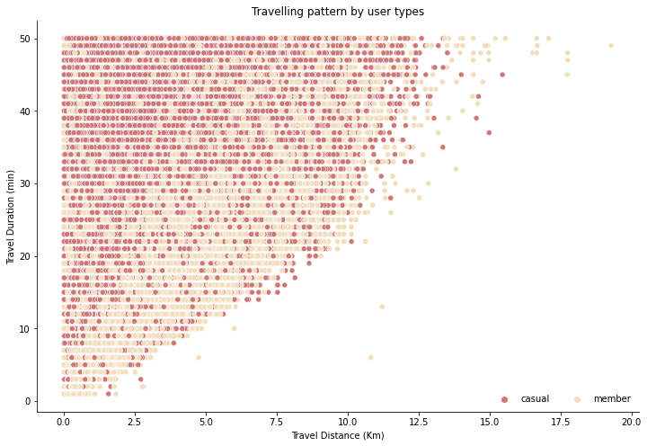

```python
plt.figure(figsize=(12,8))
ax = sns.scatterplot(x=df['travel_distance'], y=df['travel_duration_in_mins'], hue = df['member_casual'], palette=['#CE7777', '#F2DEBA'] )
ax.set_xlabel('Travel Distance (Km)')
ax.set_ylabel('Travel Duration (min)')
ax.set_title('Travelling pattern by user types')
plt.legend(loc = "lower right", ncol = 2, frameon = False)
sns.despine()
```

### Talk about some of the relationships you observed in this part of the investigation. Were there features that strengthened each other in terms of looking at your feature(s) of interest?

The multivariate exploration strengthened some of the patterns discovered in the previous univariate and bivariate exploration , the relationship between the multiple variables plotted are visualized altogether and information are presented combined.

- The efficient/short period of usage of the member corresponds to their high concentration on rush hours Monday through Friday , indicating the use is primarily for work commute.
- The more relaxing and flexible pattern of casusal user shows that they're taking advantage of the bike sharing system quite differently from the members, heavily over weekends and in the afternoon, for city tour or leisure purpose probably.
- For travelling a longer distance electric bikes are used than the classic.

### Were there any interesting or surprising interactions between features?

The interactions between features are all supplementing each other and quite make sense when looked at combined, The small suprise was people are getting used to electric bikes. I hope the usage in electric vehicles grow in the upcoming years.